# Read parent sample from Sami's list

## Étienne list (SPIRou+NIRPS)

```python
df_etienne = pd.read_csv(path_llp2024 + "all_nirps_spirou_UCD.csv") # Shared by Étienne in confidence on 2024-02-19.

# Remove duplication (only TRAPPIST-1 in this case)
df_etienne_uniq = df_etienne.drop_duplicates(keep="first", subset=["OBJNAME", "RA", "Dec"]).reset_index(drop=True)
df_etienne_uniq.shape
```

```
(54, 7)
```

```python
arr_gaia_ra, arr_gaia_dec = np.array(df_every["gaia_ra"]), np.array(df_every["gaia_dec"])
list_match_i, list_match_on, list_every_i = [], [], []

search_radi_et = 1/60/2 #degree

for i, objname in enumerate(df_etienne_uniq["OBJNAME"]):
    checkra = df_etienne_uniq["RA"][i]
    checkdec = df_etienne_uniq["Dec"][i]
    closest_indices = np.argsort(np.abs(arr_gaia_ra - checkra))[:10]
    closest_index = np.argmin(np.abs(arr_gaia_dec[closest_indices] - checkdec))
    if ((arr_gaia_ra[closest_indices[closest_index]] - checkra)**2 + (arr_gaia_dec[closest_indices[closest_index]] - checkdec)**2)**(1/2) < search_radi_et:
        list_match_i.append(i)
        #list_match_on.append(objname)
        #print("------------")
        #print(checkra)
        #print(closest_index)
        #print(closest_index, closest_indices[closest_index])
        #print(arr_gaia_ra[closest_indices[closest_index]], arr_gaia_dec[closest_indices[closest_index]])
        list_every_i.append(closest_indices[closest_index])
        #print(objname)
print(len(list_every_i))
```

```
25
```

```python
df_etienne_overlap = df_every.iloc[list_every_i, :]
df_etienne_uniq_ol = df_etienne_uniq.iloc[list_match_i]
df_etienne_overlap_c = pd.concat([df_etienne_uniq_ol.reset_index(drop=True), df_etienne_overlap.reset_index(drop=True)], axis=1)
#pd.DataFrame(list_match_on, columns=["OBJNAME",])

df_etienne_overlap_c_single = df_etienne_overlap_c[~df_etienne_overlap_c["binary_flag"]].reset_index(drop=True)

#chk
print(df_etienne_overlap_c.shape, df_etienne_overlap_c_single.shape)
df_etienne_overlap_c_single[["OBJNAME", "RA", "gaia_ra", "Dec", "gaia_dec", "2mass_id", "j_mag", "binary_flag", "DR3_parallax", "DR3_G_mag", "DR3_BP_mag", "DR3_RP_mag", "bp_rp", "teff_k", "Teff [K]"]]
```

```
(25, 153) (16, 153)
```

|  | OBJNAME | RA | gaia_ra | Dec | gaia_dec | 2mass_id | j_mag | binary_flag | DR3_parallax | DR3_G_mag | DR3_BP_mag | DR3_RP_mag | bp_rp | teff_k | Teff [K] |
| --- | --- | --- | --- | --- | --- | --- | --- | --- | --- | --- | --- | --- | --- | --- | --- |
| 0 | J1835379P325954 | 278.907449 | 278.907449 | 32.994787 | 32.994787 | 18353790+3259545 | 10.270 | False | 175.792967 | 14.850962 | 18.456402 | 13.305739 | 5.150662 | NaN | 2400.0 |
| 1 | TRAPPIST1 | 346.626522 | 346.626522 | -5.043528 | -5.043528 | 23062928-0502285 | 11.354 | False | 80.212316 | 15.622554 | 19.005802 | 14.103951 | 4.901851 | 2490.0 | 2400.0 |
| 2 | J013656P093347 | 24.241250 | 24.241250 | 9.563070 | 9.563070 | 01365662+0933473 | 13.455 | False | 163.447846 | 19.461197 | 21.107285 | 17.640982 | 3.466303 | NaN | 1200.0 |
| 3 | SCR_J1845M6357 | 281.297227 | 281.298044 | -63.960649 | -63.960567 | 18450541-6357475 | 9.544 | False | 249.665146 | 14.005345 | 17.564142 | 12.451222 | 5.112920 | 2350.0 | 2420.0 |
| 4 | DENIS_J104814_6M395606 | 162.053888 | 162.053888 | -39.939626 | -39.939626 | 10481463-3956062 | 9.538 | False | 247.215587 | 14.005882 | 17.617006 | 12.463350 | 5.153656 | 2350.0 | 2500.0 |
| 5 | SIPS_J1259M4336 | 194.776433 | 194.776645 | -43.607927 | -43.607964 | 12590470-4336243 | 10.534 | False | 129.428790 | 14.833730 | 18.276545 | 13.307965 | 4.968579 | 2400.0 | 2500.0 |
| 6 | LP_938M71 | 15.720704 | 15.720962 | -37.627744 | -37.627709 | 01025100-3737438 | 11.130 | False | 88.291484 | 15.338341 | 18.762997 | 13.824637 | 4.938359 | 2500.0 | 2600.0 |
| 7 | LP_851M346 | 178.926805 | 178.926749 | -22.417139 | -22.417165 | 11554286-2224586 | 10.930 | False | 91.269170 | 15.096619 | 18.399044 | 13.592555 | 4.806489 | 2500.0 | 2600.0 |
| 8 | LP885M35 | 33.787358 | 33.787482 | -30.668606 | -30.668656 | 02150802-3040011 | 11.617 | False | 71.162014 | 15.840613 | 19.138403 | 14.321800 | 4.816603 | 2500.0 | 2600.0 |
| 9 | GJ3252 | 57.750162 | 57.750163 | -0.881169 | -0.881234 | 03510004-0052452 | 11.302 | False | 68.121783 | 15.313112 | 18.285807 | 13.841703 | 4.444103 | 2600.0 | 2600.0 |
| 10 | TIC_24721262 | 81.344952 | 81.344952 | -7.461603 | -7.461603 | 05252276-0727414 | 13.813 | False | 19.039155 | 17.575920 | 20.060219 | 16.139853 | 3.920366 | 2711.0 | 2650.0 |
| 11 | TIC304392811 | 352.841041 | 352.841055 | -27.827238 | -27.827134 | 23312174-2749500 | 11.646 | False | 73.378525 | 15.870283 | 19.513872 | 14.346644 | 5.167228 | 2498.0 | 2650.0 |
| 12 | GAIA_DR2_3158586539384211840 | 102.763184 | 102.763184 | 9.943411 | 9.943411 | 06510316+0956376 | 13.127 | False | 24.056023 | 17.004633 | 19.823122 | 15.550273 | 4.272849 | 2630.0 | 2650.0 |
| 13 | GJ3877 | 224.157037 | 224.156959 | -28.167137 | -28.167254 | 14563831-2809473 | 9.965 | False | 141.789120 | 14.061078 | 17.335106 | 12.566201 | 4.768905 | 2500.0 | 2680.0 |
| 14 | LP888M18 | 52.876327 | 52.876336 | -30.712520 | -30.712576 | 03313025-3042383 | 11.360 | False | 79.946846 | 15.628402 | 19.028793 | 14.108879 | 4.919914 | 2453.0 | 2700.0 |
| 15 | TVLM_513M46 | 225.283909 | 225.283902 | 22.833647 | 22.833638 | 15010818+2250020 | 11.866 | False | 93.165512 | 16.509804 | 20.133026 | 14.949882 | 5.183144 | 2284.0 | 2868.0 |

### Cross-match with DataFrame containing archive-data information

```python
i_single_etienne_overlap = []
for twomassid_match in df_etienne_overlap_c_single["2mass_id"]:
    i_single_etienne_overlap.append(np.where(df_single["2mass_id"] == twomassid_match)[0][0])
```

```python
dseo_single = df_single.iloc[i_single_etienne_overlap].reset_index(drop=True)[["gaia_source_id"]]
print(arr_ANY_ap[i_single_etienne_overlap])
dseo_cfht = pd.DataFrame(arr_CFHT[i_single_etienne_overlap], columns=["CFHT"])
dseo_apogee = pd.DataFrame(arr_SDSS[i_single_etienne_overlap], columns=["APOGEE"])
dseo_ESO = pd.DataFrame(arr_ESO[i_single_etienne_overlap], columns=["ESO"])
dseo_Keck = pd.DataFrame(arr_KOA[i_single_etienne_overlap], columns=["Keck"])
dseo_Subaru = pd.DataFrame(arr_SMOKA[i_single_etienne_overlap], columns=["Subaru"])
#dseo_IGRINS = pd.DataFrame(arr_igrins[i_single_etienne_overlap], columns=["IGRINS"])
#dseo_GNIRS = pd.DataFrame(arr_gnirs[i_single_etienne_overlap], columns=["GNIRS"])
#, dseo_IGRINS, dseo_GNIRS
dseo_Gemini = pd.DataFrame((arr_igrins + arr_gnirs)[i_single_etienne_overlap], columns=["Gemini"])

#arr_KOA + arr_ESO + arr_igrins + arr_gnirs + arr_SMOKA + arr_SDSS_rev + arr_CFHT


pd.concat([df_etienne_overlap_c_single[["OBJNAME", "gaia_ra", "gaia_dec", "j_mag"]], dseo_cfht, dseo_Gemini, dseo_Subaru, dseo_Keck, dseo_ESO, dseo_apogee], axis=1)
# df_etienne_overlap_c_single_archive_data_num_ScS240219.png
```

```
[ 437 1831  213   26  105   88    4    6    4    5   10   16   10  136
   30   69]
```

[output not shown]

## UltracoolSheet

[UCS](https://zenodo.org/records/10573247)

```python
# Downloaded from the "Main" sheet of UCS on 2024-03-11.
df_UCS = pd.read_csv(path_llp2024 + "UltracoolSheet - Main240311.csv", low_memory=False, dtype = 'object')
#df_UCS_Stan = pd.read_csv("/Users/chonmac/Downloads/UltracoolSheet_Jlt14_L+dwarfs_single/Main-表1.csv", dtype = 'object')
#"""Ldwarfs
#    Single
#    Jmag < 14
#    (240304)
#    """
#df_UCS_Stan.shape -> #(105, 242)

list_columns_astyped_to_float = ["ra_j2000_formula", "dec_j2000_formula", "sptnumabs_formula", "sep_companion", "J_2MASS", "r_P1", "G_Gaia", "RP_Gaia", "BP_Gaia", "plx_Gaia", "dist_plx_formula"]
for catf in list_columns_astyped_to_float:
    df_UCS[catf] = df_UCS[catf].astype(float)
print(np.any(df_UCS["sourceID_Gaia_DR3"].isna()))
df_UCS["sourceID_Gaia_DR2"] = df_UCS["sourceID_Gaia_DR2"].fillna(0).astype(int)
df_UCS["sourceID_Gaia_DR3"] = df_UCS["sourceID_Gaia_DR3"].fillna(0).astype(int)

if 1:
    print(len(df_UCS))

    df_UCS_singlelike = df_UCS[~df_UCS["multiplesystem_unresolved_in_this_table"].str.startswith("Y:")].reset_index(drop=True)
    #df_UCS_single = df_UCS[df_UCS["multiplesystem_unresolved_in_this_table"] == "N"].reset_index(drop=True)
    print(len(df_UCS_singlelike))

    df_UCS_singlelike_14 = df_UCS_singlelike[df_UCS_singlelike["J_2MASS"] < 14]
    print(len(df_UCS_singlelike_14))

    df_UCS_single_14_LT = df_UCS_singlelike_14[df_UCS_singlelike_14["sptnumabs_formula"] >= 10]
    print(len(df_UCS_single_14_LT), "objects are L0 or later")

    df_UCS_single_14_M6later = df_UCS_singlelike_14[df_UCS_singlelike_14["sptnumabs_formula"] >= 6] #7
    print(len(df_UCS_single_14_M6later), "objects are M6 or later")

#chk
df_UCS_single_14_LT[["spt_opt", "spt_ir", "sptnum_formula", "sptnumabs_formula"]]
#df_UCS_single_14[["spt_opt", "spt_ir", "sptnum_formula", "sptnumabs_formula"]]

#chk
#print("2747910730136768768" in df_UCS["sourceID_Gaia_DR3"].values,
#      "2747910730136768512" in df_UCS["sourceID_Gaia_DR3"].values)
#df_UCS[df_UCS["sourceID_Gaia_DR3"] == "2747910730136768768"]["sourceID_Gaia_DR3"]
```

[output not shown]

|  | spt_opt | spt_ir | sptnum_formula | sptnumabs_formula |
| --- | --- | --- | --- | --- |
| 31 | L0 | M7.4 INT-G | 10 | 10.0 |
| 57 | L2 | L1.0 | 12 | 12.0 |
| 126 | L3.5 | L4: | 13.5 | 13.5 |
| 153 | L2 beta | L2: VL-G | 12 | 12.0 |
| 169 | L1: | L0.5 | 11 | 11.0 |
| ... | ... | ... | ... | ... |
| 3304 | L2.5 | L2 | 12.5 | 12.5 |
| 3386 | L0 | NaN | 10 | 10.0 |
| 3495 | L1.5 | L0.6 | 11.5 | 11.5 |
| 3595 | L0 beta | L2: INT-G | 10 | 10.0 |
| 3634 | NaN | L1: | 11 | 11.0 |

110 rows × 4 columns

```python
# Separation of the higher mass companion if one exists
# (arcsec)

print( np.sort(pd.unique(df_UCS_single_14_LT["sep_companion"])) )
print( np.sort(pd.unique(df_UCS_single_14_M6later["sep_companion"])) )
```

```
[ 2.9    3.137 11.94  12.13  16.8   17.1      nan]
[  0.33    1.9     2.9     3.137   3.3     4.17    5.6     5.9     6.
   8.     10.5    11.94   12.     12.13   12.74   16.8    17.1    20.
  20.5    21.     26.7    31.4    33.6    34.4    36.1    52.6    66.
  75.     75.5    82.1   103.    106.1   132.6   136.1   143.    158.2
 169.    204.    235.    265.        nan]
```

```python
#chk

df_UCS_singlelike = df_UCS[~df_UCS["multiplesystem_unresolved_in_this_table"].str.startswith("Y:")].reset_index(drop=True)
print(df_UCS_singlelike.shape)
print(  pd.unique(df_UCS_singlelike["multiplesystem_unresolved_in_this_table"])  )
```

```
(3717, 242)
['N' 'Y?: Bern10;Pope13' 'Y?: Pope13' 'Y?: Bern10' 'Y?: Cali19']
```

### Cross-match (UCS vs ours)

```python
# Cross-match the objects in UCS with our sample

from astropy.coordinates import SkyCoord
from astropy import units as u
import pandas as pd

radius_conesearch = 5*u.arcmin #30*u.arcmin
criteria_jmagdiff = 1 #10

df_1 = df_single_ANY_ap
df_2 = df_UCS_single_14_M6later #df_UCS_single_14_LT

# Convert RA and Dec from both dataframes into SkyCoord objects
coords_sample2 = SkyCoord(ra=df_2["ra_j2000_formula"].values*u.degree,
                           dec=df_2["dec_j2000_formula"].values*u.degree)
coords_sample1 = SkyCoord(ra=df_1["gaia_ra"].values*u.degree,
                         dec=df_1["gaia_dec"].values*u.degree)

# Perform the cross-match with 1 arcsec search radius
idx_1, idx_2, d2d, _ = coords_sample2.search_around_sky(coords_sample1, radius_conesearch)

# Initialize a list to hold indices of rows to drop based on Jmag difference
indices_to_drop = []

for i, (index_car, index_sin) in enumerate(zip(idx_2, idx_1)):
    jmag_diff = abs(df_2.iloc[index_car]["J_2MASS"] - df_1.iloc[index_sin]["j_mag"])
    jmag_mean = (df_2.iloc[index_car]["J_2MASS"] + df_1.iloc[index_sin]["j_mag"]) / 2
    percentage_diff = (jmag_diff / jmag_mean) * 100

    # Check if the difference is more than 10%
    if percentage_diff > criteria_jmagdiff:
        warning_msg = f"Warning: Target {df_2.iloc[index_car]['name']} excluded due to Jmag difference of {percentage_diff:>5.2f} %" # > 10%
        print(warning_msg)
        #print(df_1.iloc[index_sin])
        #print(df_2.iloc[index_car])
        #print(df_1.iloc[index_sin]["j_mag"], df_2.iloc[index_car]["J_2MASS"],)
        #print(df_2.iloc[index_car]["sep_companion"],)
        indices_to_drop.append(i)

    elif df_2.iloc[index_car]["sourceID_Gaia_DR3"] != df_1.iloc[index_sin]["gaia_source_id"]:
        warning_msg = f"Warning: Gaia source ID of {df_2.iloc[index_car]['name']} is {df_2.iloc[index_car]['sourceID_Gaia_DR3']} that is mismatched to our sample, so was excluded." # > 10%
        #print(warning_msg)
        indices_to_drop.append(i)

# Remove the matches with Jmag difference > 10%
filtered_idx_2 = [i for j, i in enumerate(idx_2) if j not in indices_to_drop]
filtered_idx_1 = [i for j, i in enumerate(idx_1) if j not in indices_to_drop]
print(len(filtered_idx_1) == len(filtered_idx_2))

# Create the final matched DataFrame
matched_df = pd.DataFrame({
    "Name": df_2.iloc[filtered_idx_2]["name_simbadable"].values,
    "RAucs": df_2.iloc[filtered_idx_2]["ra_j2000_formula"].values,
    "DECucs": df_2.iloc[filtered_idx_2]["dec_j2000_formula"].values,
    "Jmag_2MASS": df_2.iloc[filtered_idx_2]["J_2MASS"].values,
    "rmag_PanSTARS": df_2.iloc[filtered_idx_2]["r_P1"].values,
    "G_Gaia": df_2.iloc[filtered_idx_2]["G_Gaia"].values,
    "RP_Gaia": df_2.iloc[filtered_idx_2]["RP_Gaia"].values,
    "BP_Gaia": df_2.iloc[filtered_idx_2]["BP_Gaia"].values,
    "plx_Gaia": df_2.iloc[filtered_idx_2]["plx_Gaia"].values,
    "dist_plx_formula": df_2.iloc[filtered_idx_2]["dist_plx_formula"].values,
    "ref_photom_Gaia": df_2.iloc[filtered_idx_2]["ref_photom_Gaia"].values,
    "sourceID_Gaia_DR3": df_2.iloc[filtered_idx_2]["sourceID_Gaia_DR3"].values,
    "sourceID_Gaia_DR2": df_2.iloc[filtered_idx_2]["sourceID_Gaia_DR2"].values,
    "sptnumabs_formula": df_2.iloc[filtered_idx_2]["sptnumabs_formula"].values,
    "gaia_source_id": df_1.iloc[filtered_idx_1]["gaia_source_id"].values,
    "gaia_ra": df_1.iloc[filtered_idx_1]["gaia_ra"].values,
    "gaia_dec": df_1.iloc[filtered_idx_1]["gaia_dec"].values,
    "j_mag": df_1.iloc[filtered_idx_1]["j_mag"].values,
    "h_mag": df_1.iloc[filtered_idx_1]["h_mag"].values,
    "k_mag": df_1.iloc[filtered_idx_1]["k_mag"].values,
    "Pan_r_Mag": df_1.iloc[filtered_idx_1]["Pan_r_Mag"].values,
    "absG_DR3": df_1.iloc[filtered_idx_1]["absG_DR3"].values,
    "DR3_G_mag": df_1.iloc[filtered_idx_1]["DR3_G_mag"].values,
    "DR3_RP_mag": df_1.iloc[filtered_idx_1]["DR3_RP_mag"].values,
    "abs_rpmag_1": df_1.iloc[filtered_idx_1]["abs_rpmag_1"].values,
    "g_rp": df_1.iloc[filtered_idx_1]["g_rp"].values,
    "NIRSPEC": df_1.iloc[filtered_idx_1]["NIRSPEC"].values,
    "ESO": df_1.iloc[filtered_idx_1]["ESO"].values,
    "IGRINS": df_1.iloc[filtered_idx_1]["IGRINS"].values,
    "Subaru": df_1.iloc[filtered_idx_1]["Subaru"].values,
    "CFHT": df_1.iloc[filtered_idx_1]["CFHT"].values,
    "CARMENES": df_1.iloc[filtered_idx_1]["CARMENES"].values,
    "archive_any_higherR": df_1.iloc[filtered_idx_1]["archive_any_higherR"].values,
    "archive_any_lowerR": df_1.iloc[filtered_idx_1]["archive_any_lowerR"].values,
    "archive_any": df_1.iloc[filtered_idx_1]["archive_any"].values,
    })

#print(matched_df)
print()
print("The number of matched objects: ", len(matched_df))
print()

# BU
# []の中の数字は、Before the revision of binary-cut by Sami
# df_single_ANY_ap and df_UCS_Stan -> The number of matched objects:  87[97] (out of 105)
# df_single_ANY_ap and df_UCS_single_14_LT -> The number of matched objects:  87[98] (out of 110)
# df_single_ANY_ap and df_UCS_single_14_M6later -> The number of matched objects:  372[394] (out of 567)
#     Warning: Target 2MASS J16334976-6808488 excluded due to Jmag difference of  3.27 % -> 確認済み（http://simbad.cds.unistra.fr/simbad/sim-id?Ident=**+KPP+2977&NbIdent=query_hlinks&Coord=16+33+48.95712-68+08+51.6804&children=2&submit=children&hlinksdisplay=h_all）

print("Original our sample :\t", len(df_single_ANY_ap)) #3951[4078]
print("Single Ldwarfs in UCDs with Jmag < 14 :\t", len(df_UCS_single_14_M6later))

#✔︎2024/03/10 17:09:13:
#軽く考えて思いつく理由の可能性としては、
#		(1) Unresolved binary
#		(2) Too early type (too blue/too bright) for Sami's criteria
#	これらが主な理由であるなら、G-GRP color-magnitude diagram上での位置を調べればわかりそう。 @確認
#   ただしまず先に、（この分を除いた）SPIRouターゲットの情報を整理せよ！！！
```

[output not shown]

```python
#chk T dwarfs
print( np.sort(df_UCS_single_14_LT["sptnumabs_formula"] * -1)[:5] )
print( np.sort(matched_df["sptnumabs_formula"] * -1)[:5])
```

```
[-26.  -25.  -24.5 -22.5 -18. ]
[-15.  -15.  -15.  -15.  -14.5]
```

```
All UCS-cross-matched L/T dwarfs 86 brighter than Jmag of 13.9969997406006
```

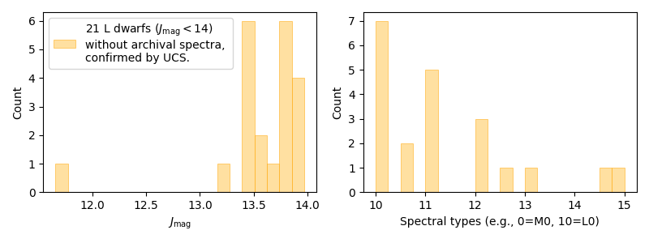

```
all L dwarfs without archive spectra: 21
all L dwarfs with existing archive spectra: 65
accessible from VLT: 15
accessible from VLT, winter semester: 10
```

```python
#test240320 for CRIRES proposal!

#matched_df_LT = matched_df.copy() # z<- crossmatch between `df_single_ANY_ap` and `df_UCS_single_14_LT`
print("All UCS-cross-matched L/T dwarfs", len(matched_df_LT), "brighter than Jmag of", matched_df_LT["j_mag"].max())

matched_df_LT_noarchive = matched_df_LT[matched_df_LT["archive_any"]==0] #archive_any_higherR, archive_any_lowerR
matched_df_LT_yesarchive = matched_df_LT[matched_df_LT["archive_any"]>0] #archive_any_higherR, archive_any_lowerR


if True:
        N_panel = 2
        fig, axes = plt.subplots(figsize=(4*N_panel, 3), nrows=1, ncols=N_panel, tight_layout=True)
        bincolor, edgecolor, linew, alp, nbin, = tcp[1], 'orange', 0.5, 0.70, 20
        #fig, ax = plt.subplots(figsize=(4, 3), tight_layout=True)

        i_panel = 0
        axes[i_panel].hist(matched_df_LT_noarchive["j_mag"], alpha=alp, bins=nbin, # range=xrange,
                label=f"{len(matched_df_LT_noarchive)} L dwarfs" + " ($J_\mathrm{mag}<$" + f"{14})" +
                " \nwithout archival spectra, \nconfirmed by UCS.", #, DEC>{dec_limit})",
                edgecolor=edgecolor, linewidth=linew, color=bincolor) #silver
        axes[i_panel].set_ylabel("Count"); axes[i_panel].set_xlabel("$J_\mathrm{mag}$"); axes[i_panel].legend(loc=2)

        i_panel = 1
        axes[i_panel].hist(matched_df_LT_noarchive["sptnumabs_formula"], alpha=alp, bins=nbin, # range=xrange,
                #label=f"{len(matched_df_LT_noarchive)} targets for SNR of {Targeted_SNR}" ,
                edgecolor=edgecolor, linewidth=linew, color=bincolor) #silver
        axes[i_panel].set_ylabel("Count"); axes[i_panel].set_xlabel("Spectral types (e.g., 0=M0, 10=L0)")#; axes[i_panel].legend(loc=2)
        #Sp.types

        #plt.title("L dwarfs without archival spectra, confirmed by the cross-match with UCS")

        if 1:
                plt.savefig(path_llp2024 + "hist_matched_df_LT_noarchive.pdf")
        plt.show()

dec_limit_VLT = +30 #15
ra_lim = [21, 15] #[21.25, 14.75] #[19, 11] for CFHT, Gemini or Subaru? #[21, 9] #19h–11h
matched_df_LT_noarchive_South = matched_df_LT_noarchive[matched_df_LT_noarchive["gaia_dec"] < dec_limit_VLT].reset_index(drop=True)
if ra_lim[0] > ra_lim[1]:
    matched_df_LT_noarchive_South_Winter = matched_df_LT_noarchive_South.iloc[np.where((matched_df_LT_noarchive_South["gaia_ra"] > ra_lim[0]/24*360) | (matched_df_LT_noarchive_South["gaia_ra"] < ra_lim[1]/24*360))[0]].reset_index(drop=True)
else:
    matched_df_LT_noarchive_South_Winter = matched_df_LT_noarchive_South.iloc[np.where((matched_df_LT_noarchive_South["gaia_ra"] > ra_lim[0]/24*360) & (matched_df_LT_noarchive_South["gaia_ra"] < ra_lim[1]/24*360))[0]].reset_index(drop=True)

print("all L dwarfs without archive spectra:", len(matched_df_LT_noarchive))
print("all L dwarfs with existing archive spectra:", len(matched_df_LT_yesarchive)) # NOT? includnig small number of T dwarfs, too
print("accessible from VLT:", len(matched_df_LT_noarchive_South))
print("accessible from VLT, winter semester:", len(matched_df_LT_noarchive_South_Winter))
```

```python
# Objects that are not cross-matched (i.e. in UCS but not in ours)

idx_not_cross_matched_objects = np.setdiff1d(np.arange(len(df_2)), filtered_idx_2)
print(len(idx_not_cross_matched_objects))

notmatched_df = pd.DataFrame({
    "Name": df_2.iloc[idx_not_cross_matched_objects]["name_simbadable"].values,
    "RAucs": df_2.iloc[idx_not_cross_matched_objects]["ra_j2000_formula"].values,
    "DECucs": df_2.iloc[idx_not_cross_matched_objects]["dec_j2000_formula"].values,
    "Jmag_2MASS": df_2.iloc[idx_not_cross_matched_objects]["J_2MASS"].values,
    "rmag_PanSTARS": df_2.iloc[idx_not_cross_matched_objects]["r_P1"].values,
    "G_Gaia": df_2.iloc[idx_not_cross_matched_objects]["G_Gaia"].values,
    "RP_Gaia": df_2.iloc[idx_not_cross_matched_objects]["RP_Gaia"].values,
    "BP_Gaia": df_2.iloc[idx_not_cross_matched_objects]["BP_Gaia"].values,
    "plx_Gaia": df_2.iloc[idx_not_cross_matched_objects]["plx_Gaia"].values,
    "dist_plx_formula": df_2.iloc[idx_not_cross_matched_objects]["dist_plx_formula"].values,
    "ref_photom_Gaia": df_2.iloc[idx_not_cross_matched_objects]["ref_photom_Gaia"].values,
    "sourceID_Gaia_DR3": df_2.iloc[idx_not_cross_matched_objects]["sourceID_Gaia_DR3"].values,
    "sourceID_Gaia_DR2": df_2.iloc[idx_not_cross_matched_objects]["sourceID_Gaia_DR2"].values,
    })

print(matched_df.shape, notmatched_df.shape)

#BU
# Before excluding the sourceID_Gaia_DR3 mismatch: 372 are cross-matched and 195 are not cross-matched.
#    ↓
# After excluding the sourceID_Gaia_DR3 mismatch: 137 are cross-matched and 430 are not cross-matched.
```

```
194
(373, 34) (194, 13)
```

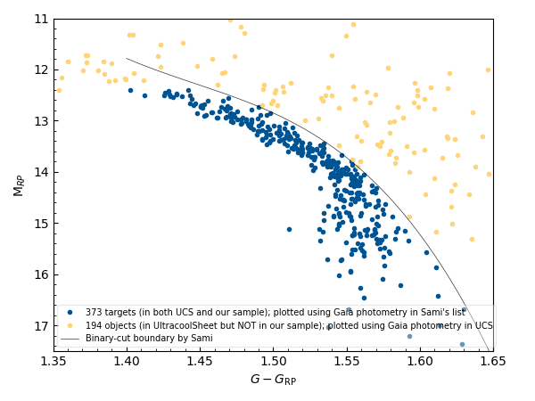

```
184 objects (out of 373 cross-matched objects) are without archival high-R spectra.
```

```python
#test240311
matched_df["absG_Gaia"] = matched_df["G_Gaia"] - 5 * np.log10(1000/matched_df["plx_Gaia"]) + 5
notmatched_df["absG_Gaia"] = notmatched_df["G_Gaia"] - 5 * np.log10(1000/notmatched_df["plx_Gaia"]) + 5
matched_df["G_RP_Gaia"] = matched_df["G_Gaia"] - matched_df["RP_Gaia"]
notmatched_df["G_RP_Gaia"] = notmatched_df["G_Gaia"] - notmatched_df["RP_Gaia"]
matched_df["absRP_Gaia"] = matched_df["RP_Gaia"] - 5 * np.log10(1000/matched_df["plx_Gaia"]) + 5
notmatched_df["absRP_Gaia"] = notmatched_df["RP_Gaia"] - 5 * np.log10(1000/notmatched_df["plx_Gaia"]) + 5

# G-RP vs G_abs
if 0:
        fig, ax = plt.subplots(figsize=(6, 4.5), tight_layout=True)

        ax.plot(matched_df["g_rp"], matched_df["absG_DR3"], ls="", marker=".", color=tcp[0], alpha=1.0,
                label=f"{len(matched_df)} targets (in both UCS and our sample); plotted using Gaia photometry in Sami's list")
        #ax.plot(matched_df["G_RP_Gaia"], matched_df["absG_Gaia"], ls="", marker="x", color=tcp[2], alpha=0.5,
        #        label=f"{len(matched_df)} targets (in both UCS and our sample); plotted using Gaia photometry in UCS (maybe EDR3 values)")
        ax.plot(notmatched_df["G_RP_Gaia"], notmatched_df["absG_Gaia"], ls="", marker=".", color=tcp[1],
                label=f"{len(notmatched_df)} objects (in UltracoolSheet but NOT in our sample)") #, zorder = -1)

        #ax.set_xlim(1.2, 2.2) # Fig2 of Reylé_2018
        #ax.set_ylim(10, 22)  Fig2 of Reylé_2018
        #ax.set_xlim(1.39, 1.6)
        #ax.set_ylim(13, 18)
        ax.set_xlim(1.3, 2.32)
        ax.set_ylim(8, 22)
        plt.xlabel("$G - G_\mathrm{RP}$")
        plt.ylabel("$\mathrm{M}_G$")

        ax.invert_yaxis()
        plt.tick_params(direction='in', which='both')
        plt.minorticks_on()
        #plt.grid(which='both', alpha=0.20)
        plt.legend(loc=3, framealpha=0.4, fontsize=7) #loc="best"

        #plt.savefig(path_llp2024 + "HRdiagram_GRP_MG_UCS_CrossmatchedOrNot.pdf") #_M7cut
        plt.show()

# G-RP vs RP_abs
if True:
        fig, ax = plt.subplots(figsize=(6, 4.5), tight_layout=True)

        ax.plot(matched_df["g_rp"], matched_df["abs_rpmag_1"], ls="", marker=".", color=tcp[0], alpha=1.0,
                label=f"{len(matched_df)} targets (in both UCS and our sample); plotted using Gaia photometry in Sami's list")
        #ax.plot(matched_df["G_RP_Gaia"], matched_df["absRP_Gaia"], ls="", marker="x", color=tcp[2], alpha=0.5,
        #        label=f"{len(matched_df)} targets (in both UCS and our sample); plotted using Gaia photometry in UCS (maybe EDR3 values)")
        ax.plot(notmatched_df["G_RP_Gaia"], notmatched_df["absRP_Gaia"], ls="", marker=".", color=tcp[1],
                label=f"{len(notmatched_df)} objects (in UltracoolSheet but NOT in our sample); plotted using Gaia photometry in UCS") #, zorder = -1)

        # Binary-cut by Sami
        xarr_bc = np.linspace(1.4, 1.65, 1000)
        offset_bc = -0.30 + 0.0004 # for 2MASS J15394442+7437273
        def sami_binary_cut(xarr_bc, offset_bc):
                return 408.32*xarr_bc**3 -1771.93*xarr_bc**2 +2572.74*xarr_bc -1237.20 + offset_bc
        yarr_bc = sami_binary_cut(xarr_bc, offset_bc)
        #ax.plot(xarr_bc, yarr_bc - offset_bc, ls="--", lw=0.5, alpha=0.8, c='salmon')
        ax.plot(xarr_bc, yarr_bc, ls="-", lw=0.5, alpha=0.8, c='k', label="Binary-cut boundary by Sami")

        notmatched_df_under_bc = notmatched_df[notmatched_df["absRP_Gaia"] > sami_binary_cut(notmatched_df["G_RP_Gaia"], offset_bc)]
        notmatched_df_under_bc_especially = notmatched_df_under_bc[(notmatched_df_under_bc["G_RP_Gaia"] > 1.42)] # & (notmatched_df_under_bc["G_RP_Gaia"] < 1.65)]
        #notmatched_df_under_bc_especially = notmatched_df_under_bc_especially[(notmatched_df_under_bc_especially["absRP_Gaia"] > 13) & (notmatched_df_under_bc_especially["absRP_Gaia"] < 14.5)]
        #ax.plot(notmatched_df_under_bc["G_RP_Gaia"], notmatched_df_under_bc["absRP_Gaia"], ls="", marker="x", color=tcp[2], alpha=0.5,
        #        label=f"{len(notmatched_df_under_bc)} objects (in UltracoolSheet but NOT in our sample) and fainter than the boundary") #, zorder = -1)
        #ax.plot(notmatched_df_under_bc_especially["G_RP_Gaia"], notmatched_df_under_bc_especially["absRP_Gaia"], ls="", marker="+", color=tcp[3], alpha=0.8,
        #        label=f"{len(notmatched_df_under_bc_especially)} objects (arbitraily selected)") #, zorder = -1)
        #ax.plot(notmatched_df_under_bc_especially["G_RP_Gaia"], notmatched_df_under_bc_especially["absRP_Gaia"], ls="", marker="x", color="fuchsia", alpha=0.8,
        #        label=f"{len(notmatched_df_under_bc_especially)} objects with attention") #, zorder = -1)

        #ax.set_xlim(1.2, 2.2) # Fig2 of Reylé_2018
        #ax.set_ylim(10, 22)  Fig2 of Reylé_2018
        #ax.set_xlim(1.39, 1.6)
        #ax.set_ylim(13, 18)
        #ax.set_xlim(1.3, 2.32)
        #ax.set_ylim(8, 22)
        #ax.set_xlim(1.40, 1.65); ax.set_ylim(12, 17.5)
        ax.set_xlim(1.35, 1.65); ax.set_ylim(11, 17.5)
        plt.xlabel("$G - G_\mathrm{RP}$")
        plt.ylabel("$\mathrm{M}_{RP}$")

        ax.invert_yaxis()
        plt.tick_params(direction='in', which='both')
        plt.minorticks_on()
        #plt.grid(which='both', alpha=0.20)
        plt.legend(loc=3, framealpha=0.4, fontsize=7) #loc="best"

        #plt.savefig(path_llp2024 + "HRdiagram_GRP_MRP_UCS_CrossmatchedOrNot.pdf") #_M7cut #_mailtoSami #_5arcminMatch
        plt.show()

matched_df_noarchive = matched_df[matched_df["archive_any"] == 0]
print(f"{len(matched_df_noarchive)} objects (out of {len(matched_df)} cross-matched objects) are without archival high-R spectra.")
```

```python
print( np.argsort(abs(matched_df["g_rp"].values - 1.5107918))[:5],
      np.argsort(abs(matched_df["abs_rpmag_1"].values - 15.111139))[:5], )
matched_df.iloc[132, :][["gaia_source_id", "sourceID_Gaia_DR3", "sourceID_Gaia_DR2", "ref_photom_Gaia",  "g_rp", "abs_rpmag_1",  "G_RP_Gaia", "absRP_Gaia",  "DR3_G_mag", "DR3_RP_mag",  "G_Gaia", "RP_Gaia"]]

# "Diff. in G:", 18.56631 - 18.5918, "Diff. in G_RP:", 17.05552 - 17.0555, 18.56631 - 17.05552, 18.5918 - 17.0555
# 主に G が違う。

# source ID が違うことに気がついた！ (240311)
```

```
[132 308 162 180 335] [132  12 350 272 303]
```

```
gaia_source_id       3058039362114874496
sourceID_Gaia_DR3    3058039362114874368
sourceID_Gaia_DR2    3058039362114874368
ref_photom_Gaia                   Gaia23
g_rp                            1.510792
abs_rpmag_1                    15.111141
G_RP_Gaia                         1.5363
absRP_Gaia                     15.111136
DR3_G_mag                       18.56631
DR3_RP_mag                      17.05552
G_Gaia                           18.5918
RP_Gaia                          17.0555
Name: 132, dtype: object
```

```python
#matched_df[["g_rp","G_RP_Gaia"]]
matched_df_diffGaiaPhoto = matched_df[abs(matched_df["g_rp"] - matched_df["G_RP_Gaia"]) > 0.01]
print(len(matched_df_diffGaiaPhoto), "/", len(matched_df))

arrtest = abs(matched_df["g_rp"] - matched_df["G_RP_Gaia"])
print(arrtest.max())

arrtest = abs(matched_df["abs_rpmag_1"] - matched_df["absRP_Gaia"])
print(arrtest.max())
```

```
81 / 137
0.025588500000000902
0.00010644352784972
```

```python
#chk
pd.unique(df_UCS_single_14_M6later["ref_photom_Gaia"]), pd.unique(matched_df["ref_photom_Gaia"]), pd.unique(notmatched_df["ref_photom_Gaia"]), \
pd.unique(df_UCS["ref_photom_Gaia"]), pd.unique(matched_df_diffGaiaPhoto["ref_photom_Gaia"]),
```

```
(array(['Gaia23', nan], dtype=object),
 array(['Gaia23'], dtype=object),
 array(['Gaia23', nan], dtype=object),
 array([nan, 'Gaia23', 'Gaia21a'], dtype=object),
 array(['Gaia23'], dtype=object))
```

```python
print( len(np.where(matched_df_diffGaiaPhoto["gaia_source_id"] != matched_df_diffGaiaPhoto["sourceID_Gaia_DR3"])[0]) )
df_falsematch = matched_df_diffGaiaPhoto[matched_df_diffGaiaPhoto["gaia_source_id"] != matched_df_diffGaiaPhoto["sourceID_Gaia_DR3"]]
#df_falsematch[["gaia_source_id", "sourceID_Gaia_DR3", "sourceID_Gaia_DR2", "ref_photom_Gaia",  "g_rp", "abs_rpmag_1",  "G_RP_Gaia", "absRP_Gaia",  "DR3_G_mag", "DR3_RP_mag",  "G_Gaia", "RP_Gaia"]]

print('"DR3_G_mag" が DR3, "G_Gaia" が DR3以前の値ということか！')
matched_df_diffGaiaPhoto[["gaia_source_id", "sourceID_Gaia_DR3", "sourceID_Gaia_DR2", "ref_photom_Gaia",  "g_rp", "abs_rpmag_1",  "G_RP_Gaia", "absRP_Gaia",  "DR3_G_mag", "DR3_RP_mag",  "G_Gaia", "RP_Gaia"]]
```

```
0
"DR3_G_mag" が DR3, "G_Gaia" が DR3以前の値ということか！
```

|  | gaia_source_id | sourceID_Gaia_DR3 | sourceID_Gaia_DR2 | ref_photom_Gaia | g_rp | abs_rpmag_1 | G_RP_Gaia | absRP_Gaia | DR3_G_mag | DR3_RP_mag | G_Gaia | RP_Gaia |
| --- | --- | --- | --- | --- | --- | --- | --- | --- | --- | --- | --- | --- |
| 0 | 1017131170037877248 | 1017131170037877248 | 1017131170037877248 | Gaia23 | 1.500471 | 13.093210 | 1.5260 | 13.093230 | 17.956179 | 16.455708 | 17.9817 | 16.4557 |
| 1 | 1022050415123922176 | 1022050415123922176 | 1022050415123922176 | Gaia23 | 1.552336 | 14.055725 | 1.5778 | 14.055739 | 17.329490 | 15.777155 | 17.3550 | 15.7772 |
| 2 | 1044279864474742272 | 1044279864474742272 | 1044279864474742272 | Gaia23 | 1.554812 | 15.101518 | 1.5804 | 15.101508 | 18.368656 | 16.813845 | 18.3942 | 16.8138 |
| 3 | 1047188004010109440 | 1047188004010109440 | 1047188004010109440 | Gaia23 | 1.549675 | 15.375500 | 1.5751 | 15.375489 | 18.264547 | 16.714872 | 18.2900 | 16.7149 |
| 4 | 105449766468765952 | 105449766468765952 | 105449766468765952 | Gaia23 | 1.560459 | 15.401435 | 1.5859 | 15.401446 | 18.789543 | 17.229084 | 18.8150 | 17.2291 |
| ... | ... | ... | ... | ... | ... | ... | ... | ... | ... | ... | ... | ... |
| 129 | 898275195732381440 | 898275195732381440 | 898275195732381440 | Gaia23 | 1.536190 | 13.838126 | 1.5617 | 13.838139 | 16.363377 | 14.827187 | 16.3889 | 14.8272 |
| 131 | 94712996769289856 | 94712996769289856 | 94712996769289856 | Gaia23 | 1.576218 | 15.245661 | 1.6017 | 15.245687 | 18.689850 | 17.113632 | 18.7153 | 17.1136 |
| 132 | 950501246430703360 | 950501246430703360 | 950501246430703360 | Gaia23 | 1.504093 | 13.179420 | 1.5296 | 13.179383 | 17.339186 | 15.835093 | 17.3647 | 15.8351 |
| 133 | 954697944875755136 | 954697944875755136 | 954697944875755136 | Gaia23 | 1.628708 | 17.355319 | 1.6542 | 17.355321 | 18.781694 | 17.152987 | 18.8072 | 17.1530 |
| 136 | 989476558517917952 | 989476558517917952 | 989476558517917952 | Gaia23 | 1.555347 | 15.184852 | 1.5808 | 15.184857 | 18.738506 | 17.183159 | 18.7640 | 17.1832 |

81 rows × 12 columns

```python
#test #True #898275195732381440 in df_single_ANY_ap["gaia_source_id"].values

print(len(notmatched_df), len(df_single_ANY_ap), len(df_every_rev))

list_notmatched_but_same_gaia_id = []
for gsid in notmatched_df["sourceID_Gaia_DR3"]:
    if gsid in df_single_ANY_ap["gaia_source_id"].values:
        print(gsid)
        list_notmatched_but_same_gaia_id.append(df_single_ANY_ap[df_single_ANY_ap["gaia_source_id"] == gsid].index[0])
print(len(list_notmatched_but_same_gaia_id))
print("Teegarden's Star と BD+44 2051B")
print("2天体くらいなら無視してもいいけど、どのタイミングで弾かれたんだろうね？ (#here\2024/03/11 13:29:25: )")

list_notmatched_but_same_gaia_id_every = []
for gsid in notmatched_df["sourceID_Gaia_DR3"]:
    if gsid in df_every_rev["gaia_source_id"].values:
        print(gsid)
        list_notmatched_but_same_gaia_id_every.append(df_every_rev[df_every_rev["gaia_source_id"] == gsid].index[0])
print(len(list_notmatched_but_same_gaia_id_every))
print("40天体はbinary-cutで弾かれたみたいね。それでも1割程度。残りの9割はなにゆえ？")

df_single_ANY_ap.iloc[list_notmatched_but_same_gaia_id]
```

[output not shown]

|  | gaia_source_id | gaia_ra | gaia_dec | gaia_ra_error | gaia_dec_error | DR3_parallax | DR3_parallax_error | gaia_pm | gaia_pmra | gaia_pmra_error | gaia_pmdec | gaia_pmdec_error | distance | DR3_RUWE | LUWE | DR3_G_mag | DR3_G_mag_error | DR3_BP_mag | DR3_BP_mag_error | DR3_RP_mag | DR3_RP_mag_error | phot_bp_rp_excess_factor | bp_rp | bp_g | g_rp | g_j_DR3 | abs_rpmag_1 | abs_jmag_1 | absG_DR3 | … |
| --- | --- | --- | --- | --- | --- | --- | --- | --- | --- | --- | --- | --- | --- | --- | --- | --- | --- | --- | --- | --- | --- | --- | --- | --- | --- | --- | --- | --- | --- | --- |
| 1505 | 35227046884571776 | 43.269642 | 16.864374 | 0.074589 | 0.076965 | 260.988441 | 0.093427 | 5122.5728 | 3429.082827 | 0.087943 | -3805.541123 | 0.083260 | 3.831559 | 1.304290 | 1.304290 | 12.263103 | 0.003030 | 15.318630 | 0.004411 | 10.790128 | 0.004117 | 1.678040 | 4.528503 | 3.055528 | 1.472975 | 3.869103 | 12.873203 | 10.477103 | 14.346209 | … |
| 3819 | 778947608243864320 | 166.352090 | 43.525908 | 0.034008 | 0.037251 | 203.832344 | 0.050037 | 4444.9106 | -4339.849578 | 0.044766 | 960.696131 | 0.041432 | 4.905686 | 1.033409 | 0.943129 | 12.257253 | 0.002876 | 14.709731 | 0.008110 | 10.854758 | 0.004069 | 1.607592 | 3.854973 | 2.452478 | 1.402494 | 3.515253 | 12.401162 | 10.288362 | 13.803618 | … |

```python
print(len(notmatched_df_under_bc_especially))
list_notmatched_but_same_gaia_id_every_mailtoSami = []
not_list_notmatched_but_same_gaia_id_every_mailtoSami = []
for gsid in notmatched_df_under_bc_especially["sourceID_Gaia_DR3"]:
    if gsid not in df_every_rev["gaia_source_id"].values:
        print(gsid)
        not_list_notmatched_but_same_gaia_id_every_mailtoSami.append(notmatched_df_under_bc_especially[notmatched_df_under_bc_especially["sourceID_Gaia_DR3"] == gsid].index[0])
    else:
        list_notmatched_but_same_gaia_id_every_mailtoSami.append(df_every_rev[df_every_rev["gaia_source_id"] == gsid].index[0])
print(len(list_notmatched_but_same_gaia_id_every_mailtoSami))

#notmatched_df_under_bc_especially.iloc[not_list_notmatched_but_same_gaia_id_every_mailtoSami]
df_every_rev.iloc[list_notmatched_but_same_gaia_id_every_mailtoSami]
```

```
3
3
```

|  | gaia_source_id | gaia_ra | gaia_dec | gaia_ra_error | gaia_dec_error | DR3_parallax | DR3_parallax_error | gaia_pm | gaia_pmra | gaia_pmra_error | gaia_pmdec | gaia_pmdec_error | distance | DR3_RUWE | LUWE | DR3_G_mag | DR3_G_mag_error | DR3_BP_mag | DR3_BP_mag_error | DR3_RP_mag | DR3_RP_mag_error | phot_bp_rp_excess_factor | bp_rp | bp_g | g_rp | g_j_DR3 | abs_rpmag_1 | abs_jmag_1 | absG_DR3 | … |
| --- | --- | --- | --- | --- | --- | --- | --- | --- | --- | --- | --- | --- | --- | --- | --- | --- | --- | --- | --- | --- | --- | --- | --- | --- | --- | --- | --- | --- | --- | --- |
| 1562 | 35227046884571776 | 43.269642 | 16.864374 | 0.074589 | 0.076965 | 260.988441 | 0.093427 | 5122.57280 | 3429.082827 | 0.087943 | -3805.541123 | 0.083260 | 3.831559 | 1.304290 | 1.304290 | 12.263103 | 0.003030 | 15.318630 | 0.004411 | 10.790128 | 0.004117 | 1.678040 | 4.528503 | 3.055528 | 1.472975 | 3.869103 | 12.873203 | 10.477103 | 14.346209 | … |
| 1766 | 3864972938605115520 | 164.103190 | 7.002727 | 0.066837 | 0.051525 | 415.179416 | 0.068371 | 4715.32960 | -3866.338275 | 0.081306 | -2699.214988 | 0.069108 | 2.408358 | 0.835335 | 0.835335 | 11.038391 | 0.003138 | 13.770287 | 0.005448 | 9.585450 | 0.004348 | 1.663252 | 4.184836 | 2.731895 | 1.452941 | 3.953391 | 12.676627 | 10.176177 | 14.129570 | … |
| 443 | 1697766388465292800 | 234.934396 | 74.624531 | 0.343459 | 0.338680 | 38.824713 | 0.343442 | 67.57196 | -43.426359 | 0.438955 | 51.769886 | 0.438193 | 25.663624 | 3.435660 | 3.344411 | 17.505274 | 0.003170 | 20.525772 | 0.124128 | 15.947856 | 0.006310 | 1.811667 | 4.577916 | 3.020498 | 1.557418 | 4.574274 | 13.893457 | 10.876557 | 15.450815 | … |

```python
print( notmatched_df_under_bc_especially["sourceID_Gaia_DR2"] == notmatched_df_under_bc_especially["sourceID_Gaia_DR3"])
notmatched_df_under_bc_especially
```

```
31      True
91     False
137     True
dtype: bool
```

|  | Name | RAucs | DECucs | Jmag_2MASS | rmag_PanSTARS | G_Gaia | RP_Gaia | BP_Gaia | plx_Gaia | dist_plx_formula | ref_photom_Gaia | sourceID_Gaia_DR3 | sourceID_Gaia_DR2 | absG_Gaia | G_RP_Gaia | absRP_Gaia |
| --- | --- | --- | --- | --- | --- | --- | --- | --- | --- | --- | --- | --- | --- | --- | --- | --- |
| 31 | NAME Teegarden's Star | 43.2537 | 16.8813 | 8.394 | NaN | 12.2631 | 10.7901 | 15.3186 | 260.9884 | 3.8316 | Gaia23 | 35227046884571776 | 35227046884571776 | 14.346206 | 1.4730 | 12.873206 |
| 91 | Wolf 359 | 164.1205 | 7.0147 | 7.085 | NaN | 11.0384 | 9.5855 | 13.7703 | 415.1794 | 2.4086 | Gaia23 | 3864972938605115520 | 0 | 14.129579 | 1.4529 | 12.676679 |
| 137 | 2MASS J15394442+7437273 | 234.9351 | 74.6243 | 12.931 | 19.7755 | 17.5053 | 15.9479 | 20.5258 | 38.8247 | 25.7700 | Gaia23 | 1697766388465292800 | 1697766388465292800 | 15.450841 | 1.5574 | 13.893441 |

```python
# LP 584-4: http://simbad.u-strasbg.fr/simbad/sim-id?Ident=LP%20584-4+&submit=submit+id
2738415592529108096 in df_every_rev["gaia_source_id"].values
# LSPM J0031+0649: http://simbad.u-strasbg.fr/simbad/sim-id?Ident=LSPM%20J0031%2B0649+&submit=submit+id
2747910730136768768 in df_every_rev["gaia_source_id"].values
```

```
True
```

## Gaia colors

Marocco_2020 says "The maximum distance is 373 pc, the distance at which the brightest, hottest UCD (Teff ∼ 2500 K) would be fainter than the Gaia limiting magnitude (G = 20.7 mag). We required the G − G_RP colour to be redder than 1.4 mag (since UCDs are typically redder than that; Smart et al. 2017, 2019)"

```
1.4000187 20.879341
```

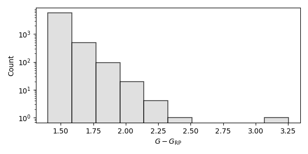

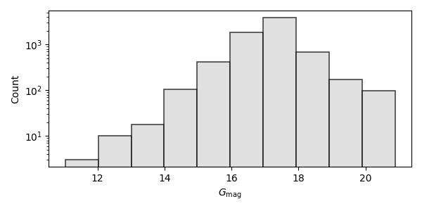

```
1.4000187 -0.23815155 1.350007 20.879341
```

```python
# Check the distribution of Gaia colors
# bp_rp, bp_g ,g_rp
# j_mag, g_j_DR3

print(df_every["g_rp"].min(), df_every["DR3_G_mag"].max())

fig, ax = plt.subplots(figsize=(6, 3), tight_layout=True)

#ax.hist(df_every["bp_rp"], alpha=0.7, label=f"", color="lightgray", edgecolor='black', linewidth=1.2)
#ax.hist(df_every["bp_g"], alpha=0.7, label=f"", color="lightgray", edgecolor='black', linewidth=1.2)
ax.hist(df_every["g_rp"], alpha=0.7, label=f"", color="lightgray", edgecolor='black', linewidth=1.2)
#ax.hist(, alpha=0.7, label=f"", edgecolor='black', linewidth=0)

plt.ylabel("Count")
plt.xlabel("$G - G_\mathrm{RP}$")
plt.yscale("log")
#plt.tick_params(direction='in', which='both')
#plt.minorticks_on()
#plt.grid(which='both', alpha=0.20)
#plt.legend(loc="best")
#plt.savefig(path_llp2024 + f"histogram_g_rp_color.pdf") #_ylinear
plt.show()

fig, ax = plt.subplots(figsize=(6, 3), tight_layout=True)
ax.hist(df_every["DR3_G_mag"], alpha=0.7, label=f"", color="lightgray", edgecolor='black', linewidth=1.2)
plt.ylabel("Count")
plt.xlabel("$G_\mathrm{mag}$")
plt.yscale("log")
#plt.savefig(path_llp2024 + f"histogram_g_mag.pdf") #_ylinear
plt.show()

print(np.min(df_every["g_rp"]), np.min(df_every["bp_g"]), np.min(df_every["bp_rp"]), np.max(df_every["DR3_G_mag"])) #chk
```

## HR diagram with Gaia photometry

g_rp, absG_DR3, abs_jmag_1, DR3_G_mag, g_j_DR3

```python
# Reylé_2018

def M_G(SpT):
    return -0.020*SpT**2 + 0.985*SpT*1 + 8.298 #M7–T6
def GminusGRP(SpT):
    return 0.029*SpT + 1.358 #M7–T6
def GminusJ(SpT):
    return 0.108*SpT + 3.603 #M9–T6
```

```python
# Objects with IRD archival spectra （240304追記）
df_archive_IRD = pd.read_csv(path_llp2024 + "df_archive_IRD.csv")
```

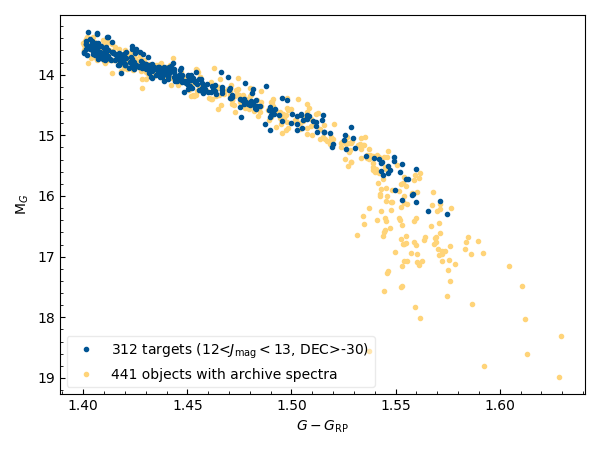

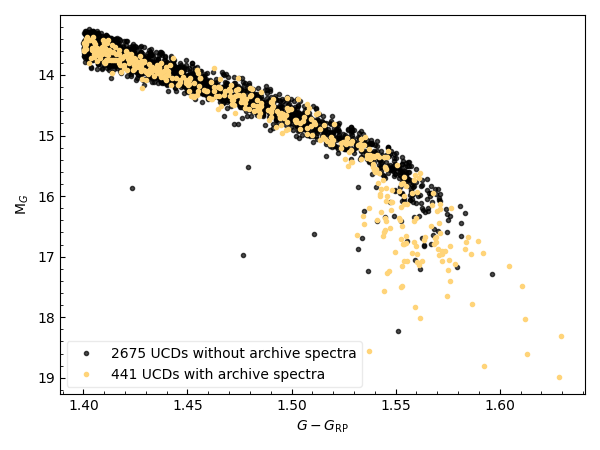

```python
if False:
        fig, ax = plt.subplots(figsize=(5, 4), tight_layout=True)

        ax.plot(df_tttvt_s_Subaru["g_rp"], df_tttvt_s_Subaru["absG_DR3"], ls="", marker=".")
        #ax.plot(sptype_df_tttvt_s_Subaru["g_rp"], sptype_df_tttvt_s_Subaru["absG_DR3"], ls="", marker="*")

        #ax.axhline(15.0, 0, 1, ls="-", lw=1.5, c="gray")

        '''ax.axhline(M_G(10), 0, 1, ls="-", lw=0.5, c="k")
        ax.axhline(M_G(9), 0, 1, ls="--", lw=0.5, c="maroon")
        ax.axhline(M_G(8), 0, 1, ls=":", lw=0.5, c="firebrick")
        ax.axhline(M_G(7), 0, 1, ls="-", lw=0.5, c="indianred")
        ax.axhline(M_G(6), 0, 1, ls="--", lw=0.5, c="lightcoral") #'''
        #ax.axvline(GminusGRP(10), 0, 1, ls="-", lw=0.5, c="k")
        #ax.axvline(GminusGRP(9), 0, 1, ls="--", lw=0.5, c="maroon")
        #ax.axvline(GminusGRP(8), 0, 1, ls=":", lw=0.5, c="firebrick")
        #ax.axvline(GminusGRP(7), 0, 1, ls="-", lw=0.5, c="indianred")
        #ax.axvline(GminusGRP(6), 0, 1, ls="--", lw=0.5, c="lightcoral")
        print(GminusGRP(6))

        #ax.set_xlim(1.2, 2.2) # Fig2 of Reylé_2018
        #ax.set_ylim(10, 22)  Fig2 of Reylé_2018
        plt.xlabel("$G - G_\mathrm{RP}$")
        plt.ylabel("$\mathrm{M}_G$")

        ax.invert_yaxis()
        plt.tick_params(direction='in', which='both')
        plt.minorticks_on()
        #plt.grid(which='both', alpha=0.20)
        #plt.legend(loc="best")

        #plt.savefig(path_llp2024 + "HRdiagram_GRP_MG_SubaruTargetCandidates.pdf") #_Reylé18criteria
        plt.show()



if 1:
        fig, ax = plt.subplots(figsize=(6, 4.5), tight_layout=True)

        ax.plot(df_tttvt_s_Subaru["g_rp"], df_tttvt_s_Subaru["absG_DR3"], ls="", marker=".", color=tcp[0],
                label=f"{len(df_tttvt_s_Subaru)} targets ({12}" + "<$J_\mathrm{mag}<$" + f"{13}, DEC>{-30})")
        ax.plot(df_yesarchive["g_rp"], df_yesarchive["absG_DR3"], ls="", marker=".", color=tcp[1],
                label=f"{len(df_yesarchive)} objects with archive spectra", zorder = -1)

        #ax.set_xlim(1.2, 2.2) # Fig2 of Reylé_2018
        #ax.set_ylim(10, 22)  Fig2 of Reylé_2018
        #ax.set_xlim(1.39, 1.6)
        #ax.set_ylim(13, 18)
        plt.xlabel("$G - G_\mathrm{RP}$")
        plt.ylabel("$\mathrm{M}_G$")

        ax.invert_yaxis()
        plt.tick_params(direction='in', which='both')
        plt.minorticks_on()
        #plt.grid(which='both', alpha=0.20)
        plt.legend(loc=3, framealpha=0.4) #loc="best"

        #plt.savefig(path_llp2024 + "HRdiagram_GRP_MG_SubaruTargetCandidates_revbinarycut.pdf") #_Reylé18criteria #_InclArchiveData
        plt.show()



if True:
        fig, ax = plt.subplots(figsize=(6, 4.5), tight_layout=True)

        ax.plot(df_noarchive["g_rp"], df_noarchive["absG_DR3"],
                ls="", marker=".", color="k", alpha=0.7,
                label=f"{len(df_noarchive)} UCDs without archive spectra") # UCD candidates
        ax.plot(df_yesarchive["g_rp"], df_yesarchive["absG_DR3"],
                ls="", marker=".", color=tcp[1],
                label=f"{len(df_yesarchive)} UCDs with archive spectra")#, zorder = -1)

        #ax.set_xlim(1.2, 2.2) # Fig2 of Reylé_2018
        #ax.set_ylim(10, 22)  Fig2 of Reylé_2018
        #ax.set_xlim(1.39, 1.6)
        ax.set_ylim(13.01, 19.27) #ax.set_ylim(13, 18)
        plt.xlabel("$G - G_\mathrm{RP}$")
        plt.ylabel("$\mathrm{M}_G$")

        ax.invert_yaxis()
        plt.tick_params(direction='in', which='both')
        plt.minorticks_on()
        #plt.grid(which='both', alpha=0.20)
        plt.legend(loc=3, framealpha=0.4) #loc="best"

        #plt.savefig(path_llp2024 + "HRdiagram_GRP_MG_archive_umu.pdf") #_Reylé18criteria #_InclArchiveData
        plt.show()
```

```python
crireria_absG = 15.0

df_baGird= df_tttvt_s_Subaru[df_tttvt_s_Subaru["absG_DR3"] < crireria_absG]
num_brighter_absG = df_baGird.shape[0]
df_faGird = df_tttvt_s_Subaru[df_tttvt_s_Subaru["absG_DR3"] >= crireria_absG]
num_fainter_absG = df_faGird.shape[0]
print(f"{num_brighter_absG} objects with M_G < {crireria_absG:>5.2f}, and {num_fainter_absG} objects with M_G > {crireria_absG:>5.2f}")
```

```
281 objects with M_G < 15.00, and 31 objects with M_G > 15.00
```

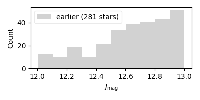

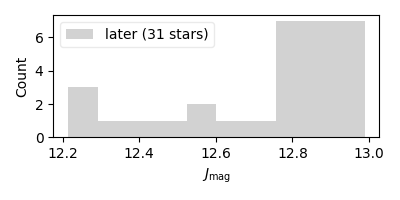

```python
fig, ax = plt.subplots(figsize=(4, 2), tight_layout=True) #(7, 3)
ax.hist(df_baGird["j_mag"], alpha=0.7, label=f"earlier ({num_brighter_absG} stars)", edgecolor='black', linewidth=0, color="silver")
#ax.hist(df_tttvsSpiT_North["h_mag"], alpha=0.7, label="$J_\mathrm{mag}<$"+f"{Jmag_spiroulimit}, DEC>{dec_boundary_cfht} ({df_tttvsSpiT_North['h_mag'].shape[0]} stars)", edgecolor='black', linewidth=0)
plt.ylabel("Count")
plt.xlabel("$J_\mathrm{mag}$")
plt.legend(loc=2, framealpha=0.4)
#plt.savefig(path_llp2024 + f"histogram_Hmag_Jmag{Jmag_spiroulimit}_as_SPIRouPItargets_North.pdf") #_ylinear
plt.show()

fig, ax = plt.subplots(figsize=(4, 2), tight_layout=True) #(7, 3)
ax.hist(df_faGird["j_mag"], alpha=0.7, label=f"later ({num_fainter_absG} stars)", edgecolor='black', linewidth=0, color="silver")
#ax.hist(df_tttvsSpiT_North["h_mag"], alpha=0.7, label="$J_\mathrm{mag}<$"+f"{Jmag_spiroulimit}, DEC>{dec_boundary_cfht} ({df_tttvsSpiT_North['h_mag'].shape[0]} stars)", edgecolor='black', linewidth=0)
plt.ylabel("Count")
plt.xlabel("$J_\mathrm{mag}$")
plt.legend(loc=2, framealpha=0.4)
#plt.savefig(path_llp2024 + f"histogram_Hmag_Jmag{Jmag_spiroulimit}_as_SPIRouPItargets_North.pdf") #_ylinear
plt.show()
```

```python
M_G(10), GminusGRP(10), GminusJ(10)
```

```
(16.148, 1.6480000000000001, 4.683)
```

```python
sptype_df_tttvt_s_Subaru = df_tttvt_s_Subaru.iloc[np.where(~df_tttvt_s_Subaru["Spec_Type"].isna())]
sptype_df_tttvt_s_Subaru = sptype_df_tttvt_s_Subaru.iloc[np.where(sptype_df_tttvt_s_Subaru["Spec_Type"] != "~")]
sptype_df_tttvt_s_Subaru[["gaia_ra", "gaia_dec", "Spec_Type", "j_mag", "absG_DR3", "g_rp", "g_j_DR3"]]
```

|  | gaia_ra | gaia_dec | Spec_Type | j_mag | absG_DR3 | g_rp | g_j_DR3 |
| --- | --- | --- | --- | --- | --- | --- | --- |
| 3 | 145.691361 | 55.517854 | M8V | 12.921 | 15.608029 | 1.552336 | 4.408490 |
| 145 | 66.779609 | 8.984102 | M8.8V | 12.920 | 15.719294 | 1.555041 | 4.460714 |
| 180 | 142.867074 | 5.471982 | M8V | 12.864 | 14.657033 | 1.507477 | 4.063383 |
| 181 | 147.342812 | 8.108553 | M7Ve | 12.305 | 15.653718 | 1.543751 | 4.458603 |
| 224 | 252.267716 | 4.749496 | M8.1V | 12.959 | 15.371870 | 1.539551 | 4.393790 |
| 225 | 243.927534 | 5.777337 | M9 | 12.880 | 16.300447 | 1.574497 | 4.672683 |
| 262 | 134.916700 | 11.758668 | M8.4V | 12.743 | 15.985387 | 1.558079 | 4.587706 |

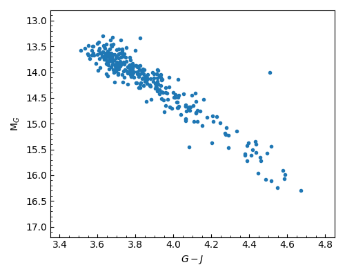

```
2
```

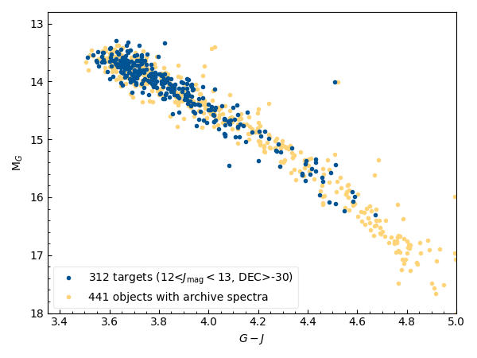

```python
fig, ax = plt.subplots(figsize=(5, 4), tight_layout=True)

ax.plot(df_tttvt_s_Subaru["g_j_DR3"], df_tttvt_s_Subaru["absG_DR3"], ls="", marker=".")
#ax.plot(sptype_df_tttvt_s_Subaru["g_j_DR3"], sptype_df_tttvt_s_Subaru["absG_DR3"], ls="", marker="*")

#ax.plot([4, 6], [17.85, 11.85], lw=0.5, c="k")
'''ax.axhline(M_G(10), 0, 1, ls="-", lw=0.5, c="k")
ax.axhline(M_G(9), 0, 1, ls="--", lw=0.5, c="maroon")
ax.axhline(M_G(8), 0, 1, ls=":", lw=0.5, c="firebrick")
ax.axhline(M_G(7), 0, 1, ls="-", lw=0.5, c="indianred")
ax.axhline(M_G(6), 0, 1, ls="--", lw=0.5, c="lightcoral") #'''
#ax.axvline(GminusJ(10), 0, 1, ls="-", lw=0.5, c="k")
#ax.axvline(GminusJ(9), 0, 1, ls="--", lw=0.5, c="maroon")
#ax.axvline(GminusJ(8), 0, 1, ls=":", lw=0.5, c="firebrick")
#ax.axvline(GminusJ(7), 0, 1, ls="-", lw=0.5, c="indianred")
#ax.axvline(GminusJ(6), 0, 1, ls="--", lw=0.5, c="lightcoral")

ax.set_xlim(3.35, 4.85) #(3, 6) # Fig7 of Reylé_2018
ax.set_ylim(12.8, 17.2) #(10, 22) # Fig7 of Reylé_2018
plt.xlabel("$G - J$")
plt.ylabel("$\mathrm{M}_G$")

ax.invert_yaxis()
plt.tick_params(direction='in', which='both')
plt.minorticks_on()
#plt.grid(which='both', alpha=0.20)
#plt.legend(loc="best")

#plt.savefig(path_llp2024 + "HRdiagram_GJ_MG_SubaruTargetCandidates.pdf") #_Reylé18criteria
plt.show()

print( len(np.where(df_tttvt_s_Subaru["absG_DR3"] > M_G(10))[0]) ) #chk



fig, ax = plt.subplots(figsize=(6, 4.5), tight_layout=True)

ax.plot(df_tttvt_s_Subaru["g_j_DR3"], df_tttvt_s_Subaru["absG_DR3"], ls="", marker=".", color=tcp[0],
        label=f"{len(df_tttvt_s_Subaru)} targets ({12}" + "<$J_\mathrm{mag}<$" + f"{13}, DEC>{-30})")
ax.plot(df_yesarchive["g_j_DR3"], df_yesarchive["absG_DR3"], ls="", marker=".", color=tcp[1],
        label=f"{len(df_yesarchive)} objects with archive spectra", zorder = -1)

#ax.set_xlim(3.35, 4.85) #(3, 6) # Fig7 of Reylé_2018
#ax.set_ylim(12.8, 17.2) #(10, 22) # Fig7 of Reylé_2018
ax.set_xlim(3.35, 5)
ax.set_ylim(12.8, 18)
plt.xlabel("$G - J$")
plt.ylabel("$\mathrm{M}_G$")

ax.invert_yaxis()
plt.tick_params(direction='in', which='both')
plt.minorticks_on()
#plt.grid(which='both', alpha=0.20)
plt.legend(loc=3, framealpha=0.4) #loc="best"

#plt.savefig(path_llp2024 + "HRdiagram_GJ_MG_SubaruTargetCandidates_revbinarycut.pdf") #_Reylé18criteria #_InclArchiveData
plt.show()
```

```python
#chk
df_tttvt_s_Subaru["DR3_G_mag"] - df_tttvt_s_Subaru["j_mag"]
df_tttvt_s_Subaru["absG_DR3"] - df_tttvt_s_Subaru["abs_jmag_1"]
df_tttvt_s_Subaru["g_j_DR3"]
# 全部大体同じ
```

```
0      3.625676
1      3.570914
2      3.894070
3      4.408490
4      3.980529
         ...
307    3.648393
308    4.062941
309    4.065620
310    3.919756
311    3.678181
Name: g_j_DR3, Length: 312, dtype: float64
```

### Estimate spectral type with Table 1 of Reylé+2018

for the spectral type distribution of IRD targets

```python
#list_sptype = ["M5.5", "M6", "M6.5", "M7", "M7.5", "M8", "M8.5", "M9", "M9.5", "L0", "L0.5", "L1", "L1.5", "L2", "L2.5", "L3", "L3.5", "L4", "L4.5", "> L5"]#, "L5.5", "L6", "L6.5", "L7"] #"M5",
#arr_M_G_mean = np.array([M_G(5.5), M_G(6), M_G(6.5), M_G(7), M_G(7.5), M_G(8), M_G(8.5), M_G(9), M_G(9.5), M_G(10), M_G(10.5), M_G(11), M_G(11.5), M_G(12), M_G(12.5), M_G(13), M_G(13.5), M_G(14), M_G(14.5), M_G(15)]) #, M_G(15.5), M_G(16), M_G(16.5), M_G(17)]) #M_G(5),
list_sptype = ["M6", "M6.5", "M7", "M7.5", "M8", "M8.5", "M9", "M9.5", "L0", "L1", "L2", "L3", "L4", "> L5"]#, "L5.5", "L6", "L6.5", "L7"] #"M5", "M5.5",
arr_M_G_mean = np.array([M_G(6), M_G(6.5), M_G(7), M_G(7.5), M_G(8), M_G(8.5), M_G(9), M_G(9.5), M_G(10), M_G(11), M_G(12), M_G(13), M_G(14), M_G(15)]) #M_G(5.5),
print(len(list_sptype) == len(arr_M_G_mean))

def estimate_SpType_Reyle18criteria(absGmag):
    #list_sptype = ["M6", "M7", "M8", "M9", "L0"]
    #arr_M_G_mean = np.array([M_G(6), M_G(7), M_G(8), M_G(9), M_G(10)])
    i_sptype = np.argmin(abs(absGmag - arr_M_G_mean))
    return list_sptype[i_sptype]

#chk
estimate_SpType_Reyle18criteria(15.608)

df_tttvt_s_Subaru = df_tttvt_s_Subaru.assign(sptype_reyle18=0)
i_column = np.where(df_tttvt_s_Subaru.keys() == "sptype_reyle18")[0][0]
for itgt, absGmag in enumerate(df_tttvt_s_Subaru["absG_DR3"]):
    df_tttvt_s_Subaru.iloc[itgt, i_column] = estimate_SpType_Reyle18criteria(absGmag)

df_yesarchive = df_yesarchive.assign(sptype_reyle18=0)
i_column = np.where(df_yesarchive.keys() == "sptype_reyle18")[0][0]
for itgt, absGmag in enumerate(df_yesarchive["absG_DR3"]):
    df_yesarchive.iloc[itgt, i_column] = estimate_SpType_Reyle18criteria(absGmag)

#chk
print( len(np.where(df_tttvt_s_Subaru["sptype_reyle18"]=="M6")[0]) )
print( len(np.where(df_yesarchive["sptype_reyle18"]=="M6")[0]) )
print( len(np.where(df_tttvt_s_Subaru["sptype_reyle18"]=="L1")[0]) )
print( len(np.where(df_yesarchive["sptype_reyle18"]=="> L5")[0]) )
print(df_tttvt_s_Subaru["sptype_reyle18"].max())
```

```
True
55
54
0
4
M9.5
```

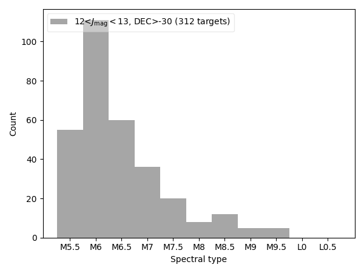

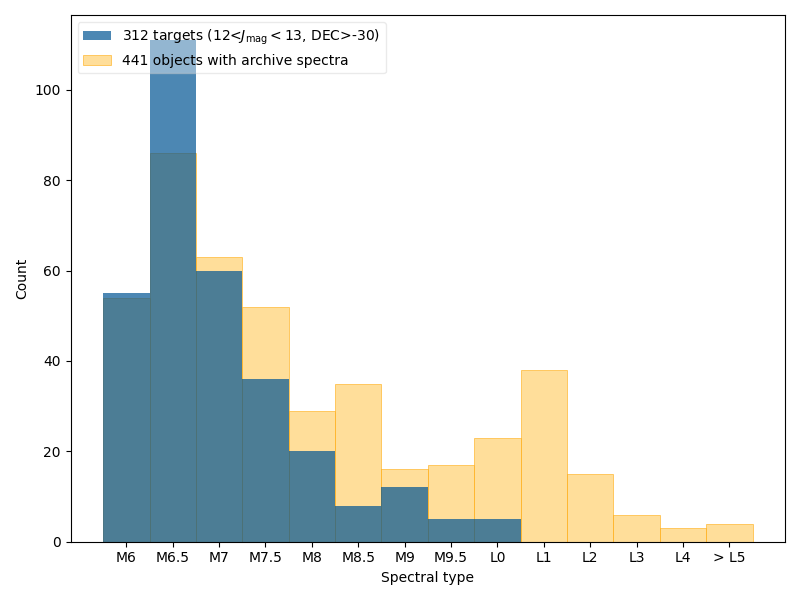

```python
# Modify the order for the plotting in order of spectral types from M6 to L0
sp_series_ordered = pd.Categorical(df_tttvt_s_Subaru["sptype_reyle18"],
                                   categories=["M5.5", "M6", "M6.5", "M7", "M7.5", "M8", "M8.5", "M9", "M9.5", "L0", "L0.5"],
                                   ordered=True)

fig, ax = plt.subplots(figsize=(6, 4.5), tight_layout=True) #(7, 3)
ax.hist(sp_series_ordered.sort_values(), alpha=0.7, label=f"{12}" + "<$J_\mathrm{mag}<$" + f"{13}, DEC>{-30} ({len(df_tttvt_s_Subaru)} targets)", edgecolor='black', linewidth=0, color="gray",
        bins=np.arange(sp_series_ordered.categories.size + 1) - 0.5) #silver
plt.ylabel("Count")
plt.xlabel("Spectral type")
ax.set_xticks(range(len(sp_series_ordered.categories)))
ax.set_xticklabels(sp_series_ordered.categories)
plt.legend(loc=2, framealpha=0.4)
#plt.savefig(path_llp2024 + f"hist_SpType_Reylé2018_for_IRD324_halfstep.pdf")
plt.show()


sp_series_ordered_yesarchive = pd.Categorical(df_yesarchive["sptype_reyle18"],
                                   categories=list_sptype,
                                   ordered=True) #["M5.5", "M6", "M6.5", "M7", "M7.5", "M8", "M8.5", "M9", "M9.5", "L0", "L0.5"],

fig, ax = plt.subplots(figsize=(8, 6), tight_layout=True) #(7, 3)
ax.hist(sp_series_ordered.sort_values(), alpha=0.7, #label=f"{12}" + "<$J_\mathrm{mag}<$" + f"{13}, DEC>{-30} ({len(df_tttvt_s_Subaru)} targets)", edgecolor='black', linewidth=0, color="gray",
        label=f"{len(df_tttvt_s_Subaru)} targets ({12}" + "<$J_\mathrm{mag}<$" + f"{13}, DEC>{-30})",
        edgecolor='orange', linewidth=0, color=tcp[0], #silver
        bins=np.arange(sp_series_ordered_yesarchive.categories.size + 1) - 0.5)
ax.hist(sp_series_ordered_yesarchive.sort_values(), alpha=0.75, # bins=20, range=(x_min, x_max),
        label=f"{len(df_yesarchive)} objects with archive spectra",
        edgecolor='orange', linewidth=0.5, color=tcp[1], zorder = -1,
        bins=np.arange(sp_series_ordered_yesarchive.categories.size + 1) - 0.5)
plt.ylabel("Count")
plt.xlabel("Spectral type")
ax.set_xticks(range(len(sp_series_ordered_yesarchive.categories)))
ax.set_xticklabels(sp_series_ordered_yesarchive.categories)
plt.legend(loc=2, framealpha=0.4)
#plt.savefig(path_llp2024 + f"hist_SpType_Reylé2018_for_IRD324_halfstep_revbinarycut.pdf") #_InclArchiveData
plt.show()
```

```python
# Identify late-M and L dwarfs to be priorityzed when I consider minimum night requirement on Subaru proposal

df_Subaru_latestsample = df_tttvt_s_Subaru[(df_tttvt_s_Subaru["sptype_reyle18"]>="M9") | (df_tttvt_s_Subaru["sptype_reyle18"]=="L0")].reset_index(drop=True)
df_Subaru_latestsample[["gaia_source_id", "sptype_reyle18", "Spec_Type", "j_mag", "absG_DR3", "g_rp", "gaia_ra", "gaia_dec"]]
```

|  | gaia_source_id | sptype_reyle18 | Spec_Type | j_mag | absG_DR3 | g_rp | gaia_ra | gaia_dec |
| --- | --- | --- | --- | --- | --- | --- | --- | --- |
| 0 | 1022050415123922176 | M9 | M8V | 12.921 | 15.608029 | 1.552336 | 145.691361 | 55.517854 |
| 1 | 1078021436789455872 | M9 | NaN | 12.916 | 15.618731 | 1.546183 | 154.995221 | 73.402421 |
| 2 | 1255034459444168704 | M9 | NaN | 12.891 | 15.421017 | 1.549378 | 218.286528 | 24.534932 |
| 3 | 13533892921879936 | M9 | NaN | 12.850 | 15.392880 | 1.541963 | 47.504618 | 7.448452 |
| 4 | 16386404041502592 | M9 | NaN | 12.463 | 15.584654 | 1.543200 | 52.146807 | 11.498831 |
| 5 | 1641189157936120704 | M9 | NaN | 12.887 | 15.573581 | 1.547154 | 237.775143 | 64.951362 |
| 6 | 1798588409277193984 | M9.5 | NaN | 12.612 | 15.713848 | 1.555967 | 321.740491 | 25.515615 |
| 7 | 2206265777300448768 | L0 | NaN | 12.779 | 16.240349 | 1.565785 | 336.448798 | 64.364746 |
| 8 | 2340736324254735488 | M9.5 | NaN | 12.404 | 15.964270 | 1.558434 | 1.176391 | -20.974588 |
| 9 | 2760661255379706240 | M9.5 | NaN | 12.798 | 15.907291 | 1.549589 | 356.690032 | 11.485592 |
| 10 | 280225450466067968 | M9 | NaN | 12.872 | 15.552118 | 1.559760 | 80.540305 | 57.900653 |
| 11 | 287949592667076864 | L0 | NaN | 12.802 | 16.106666 | 1.559875 | 85.094759 | 64.283863 |
| 12 | 3299496547982121216 | M9.5 | M8.8V | 12.920 | 15.719294 | 1.555041 | 66.779609 | 8.984102 |
| 13 | 3853943806185777664 | M9 | M7Ve | 12.305 | 15.653718 | 1.543751 | 147.342812 | 8.108553 |
| 14 | 3911082878569883264 | M9 | NaN | 12.922 | 15.502297 | 1.546337 | 174.796434 | 8.686602 |
| 15 | 4094032443707053568 | M9 | NaN | 12.795 | 15.471038 | 1.552995 | 273.621252 | -20.426462 |
| 16 | 4206320171755704320 | L0 | NaN | 12.913 | 16.087180 | 1.571497 | 286.529868 | -5.251405 |
| 17 | 4250327781042868224 | L0 | NaN | 12.533 | 16.072869 | 1.553198 | 302.647656 | 6.575968 |
| 18 | 4438043930922131072 | L0 | M9 | 12.880 | 16.300447 | 1.574497 | 243.927534 | 5.777337 |
| 19 | 5469802724480366848 | M9 | NaN | 12.791 | 15.432964 | 1.543675 | 161.320685 | -26.124297 |
| 20 | 604031766579902976 | M9.5 | M8.4V | 12.743 | 15.985387 | 1.558079 | 134.916700 | 11.758668 |
| 21 | 6281432246412503424 | M9 | NaN | 12.546 | 15.449777 | 1.543168 | 221.070955 | -20.332461 |